```python
%%javascript
IPython.OutputArea.prototype._should_scroll = function(lines) {
    return false;
}
```

```python
# to load images for this tutorial
from IPython.display import Image
import os
path = os.getcwd()
```

# Post Overview.

1. Provide an Introduction to Pearson's Product-Moment Correlation.
2. Discuss the Assumptions of a Pearson's Correlation.
3. Pearson's Correlation Coefficient Formulas.
4. Demonstrate how perform a Pearson's Correlation using SPSS.
5. Graphical Overview on Pearson's Correlation.

# Provide an introduction to Pearson's Product-Moment Correlation.

- The Pearson product-moment correlation is used to determine the strength and direction of a linear relationship between **two continuous variables**.
- The test generates a coefficient that is called the **Pearson's correlation coefficient**, denoted as \(\rho\).
- **Pearson's correlation coefficient \(\rho\)** measures the strength and direction of a linear relationship between **two continuous variables**.
- The value of the **Pearson's correlation coefficient \(\rho\)** ranges between `-1, 1`.
- A **Pearson's correlation coefficient \(\rho\)** with a value of `1` is associated with a perfect positive linear relationship.
- A **Pearson's correlation coefficient \(\rho\)** with a value of `-1` is associated with a perfect negative linear relationship.
- A **Pearson's correlation coefficient \(\rho\)** with a value of `0` is associated with no linear relationship between two variables.
- Pearson's correlation is used to determine the relationship between two quantitative variables, rather than the difference.
- Pearson's correlation also provides information as to the degree which the two variables coincide with one another.
- Relatedness can be thought of as changes in one variable would correspond to changes in the other variable.
- Pearson's correlation is one the most widely used test to measure the relationship between two sets of data. These other test include:
  - phi correlation coefficient
  - point-biserial correlation
  - Spearman’s rho
  - partial correlation
  - part correlation
- **Example case uses:**

  Determine the strength and direction of a linear relationship between
  - the Median value of owner-occupied homes (continuous) and crime incidents (continuous) in a city
  - the age of wine (continuous) and the levels of a given antioxidant (continuous)
  - salaries (continuous) and length of employment in a given industry (continuous)

# Discuss the Assuptions of a Pearson's Correlation.

**What are assumptions?**

- Assumptions are characteristics about a given data.
- A few examples of statistical assumptions include:
  - **Data types:** the data has a specific attribute (integer, continuous, categorical, string, boolean).
  - **Normality:** the data has a normal distribution.
  - **Homogeneity of variance:** the data from multiple groups have the same variance.
  - **Linearity:** the data has a linear relationship.
  - **Independence:** the data has a specific attribute.

**Why test for assumptions?**

- Statistical tests are developed making characteristics of the data into consideration
- Failure to test for these assumptions can result in inaccurate conclusions.
- Part of the process of using Pearson's Correlation is checking to make sure the data you want to analyze passes the assumptions needed for this test.
- There are **five assumptions** that must be met to give you valid results.
- It is common for data to violate some of these assumptions, and the aim of this section is to discuss how to proceed in those cases.

**The Five Assumptions**

1. Your two variables should be measured on a continuous scale.  
   **Example:** GRE scores (interval level), NFL player weights (ratio level).  
   This assumption is required to use this test.
2. Your two continuous variables are paired. In other words, each instance in your dataset has a values for each variable.  
   **Example:** To test for association between NFL players weight and height, we collect data for each instance (NFL players) and we data for the two variables we are interested in, 1) weight and 2) height.  
   This assumption is required to use this test.
3. There needs to be a linear relationship between the two variables. This can be checked by using a scatter plot and visually inspecting the graph.
4. There should be no significant outliers. Outliers are extreme data points within your sample that do no follow the pattern of the other data.  
   Pearson's Correlation is sensitive to outliers, which can influence the value of \(\rho\).
5. For inferential statistics (null hypothesis significance testing), you need to test for normality, or the assumption of bivariate normality.

# Pearsons'Correlation Coefficient Formulas.

#### Types of correlation coefficient formulas:

The formula used depends on where the data is drawn, population or a sample of the population.

1. Pearson's Correlation Coefficient expressed in terms of `x` and `y` values:
   - \[r = {n(\Sigma xy) - (\Sigma x)(\Sigma y) ) \over \sqrt{[n\Sigma x^2 - (\Sigma x)^2][n\Sigma y^2 - (\Sigma y)^2]} } \]
2. Sample Pearson's Correlation Coefficient between `x` and `y`:
   - \[r = {s_{xy} \over s_{x} s_{y}} = {\Sigma(x_{i} - \bar x) (y_{i} - \bar y) \over \sqrt{\Sigma(x_{i} - \bar x)^2 \Sigma(y_{i} - \bar y)^2} } \]
   - Where **r** = correlation coefficient.
   - **\(\mathbf{s_{xy}}\)** = is the sample covariance.
   - **\(\mathbf{s_{x}, s_{y}}\)** = sample standard deviations.
   - **\(\mathbf{x_{i}}\)** = x-variable values in a sample.
   - **\(\mathbf{y_{i}}\)** = y-variable values in a sample.
   - **\(\mathbf{\bar x, \bar y}\)** = sample means.
3. Population Pearson's Correlation Coefficient between `x` and `y`:
   - \[r = {\sigma_{xy} \over \sigma_{x} \sigma_{y}} = {\Sigma(x_{i} - \bar x) (y_{i} - \bar y) \over \sqrt{\Sigma(x_{i} - \bar x)^2 \Sigma(y_{i} - \bar y)^2} } \]
   - Where **r** = correlation coefficient.
   - **\(\mathbf{\sigma_{xy}}\)** = is the population covariance.
   - **\(\mathbf{\sigma_{x}, \sigma_{y}}\)** = population standard deviations.
   - **\(\mathbf{x_{i}}\)** = x-variable values in a sample.
   - **\(\mathbf{y_{i}}\)** = y-variable values in a sample.
   - **\(\mathbf{\bar x, \bar y}\)** = population means.

# Demonstrate how perform a Pearson's Correlation using SPSS.

#### Steps

1. Set up your data.
2. Confirm data does not violate assumption 1 (continuous variables) and 2 (instances have paired data).
3. Test for linear relationship and outliers using a scatter plot.
4. Determine if data is normally distributes by using test for normality.
5. Carry out Bivariate Pearson's Correlation and Interpret Results.
6. Graphical Overview on Pearson's Correlation.

### Step 1: Set up data

**SPSS Variable View**

- Either import or manually input data for the two variables of interest.
- In this example we want to determine if there is an association between the amount of time seated and the levels of low-density lipoprotein (LDL).
- The data is continuous, so the measure is set to `Scale`

[figure not shown]

```python
img = os.path.join(path, 'static/images/pearsons/spss1.png')
Image(filename=img,  width = 800)
```

### Step 2: Confirm data does not violate assuption 1 (continuous variables) and 2 (instances have paired data)

**SPSS Data View**

- Inspecting the data from the data view, we see that each instance (row) has a value for both the time seated variable and the low-density lipoprotein (LDL) variable.
- We also see that the data is continuous for both `time seated` and the blood levels of `low-density lipoprotein (LDL).`
- The data for both are considered `ratio` level because they have a real 0, meaning someone may not sit down at all, or LDL levels may be 0 in the blood stream. Interval level data does not have a real 0, such as GRE scores, which start at a minimal - maximum value.
- This data meets the 1st and second assumptions.

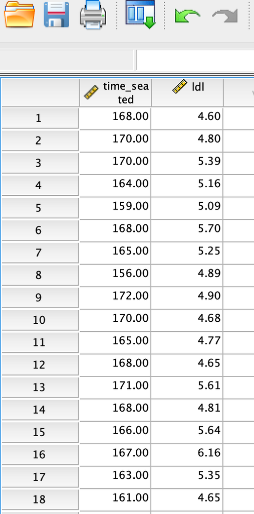

```python
img = os.path.join(path, 'static/images/pearsons/spss2.png')
Image(filename=img,  width = 200)
```

### Step 3: Test if a linear relationship exists using a scatter plot.

**Create a Scatter Plot**

1. `Graphs > Chart Builder`
2. `Gallery > Scatter/Dot.`
3. `Drag and Drop or double click Scatter/Dot to Chart Builder panel`
4. `Drag and drop variables into the X-axis or Y-axis boxes that are in the chart builder preview panel.`
5. `In element properties panel, click y-axis and adjust scale as needed.`
6. `Scale type section should have "linear" in the Type drop down. Then Click ok.`

**Interpretation of Scatter Plot**

**Test for outliers**

- **Outliers** are extreme data points that appear removed from the rest of the data set
- Based on visual inspection of scatter plot, the values for the LDL variable seems to fall within a range of `[4, 6.5]` with no extreme deviants.
- Based on visual inspection of scatter plot, the values for the time seated variable seems to fall within a range of `[155, 185]` with no extreme deviants.
- Based on visual inspection of scatter plot, there does not appear to be outliers in the data.

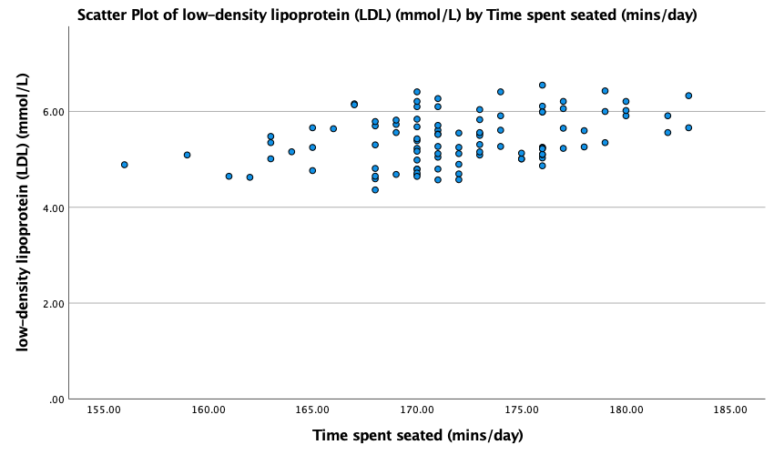

```python
img = os.path.join(path, 'static/images/pearsons/spss3.png')
Image(filename=img, width=600)
```

### Step 4: Test for normality.

**Normality test steps**

1. `Analyze > Descriptive Statistics > Explore`
2. `Explore dialogue box: Move variables to dependent list box.`
3. `Click Plots button > Boxplots select "None" Radial dial; Descriptive uncheck "stem-and-leaf", Check "Normality plots with tests > click Continue button`
4. `Returned to Explore dialogue: In Display section, select "Plots" radial dial.`
5. `Click OK button.`

**Interpretation of Results**

**Testing for normality using Normal Q-Q plots**

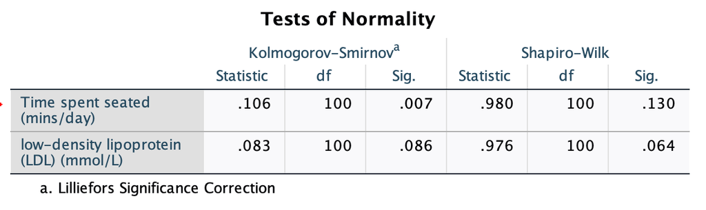

```python
img = os.path.join(path, 'static/images/pearsons/spss4.png')
Image(filename=img, width=600)
```

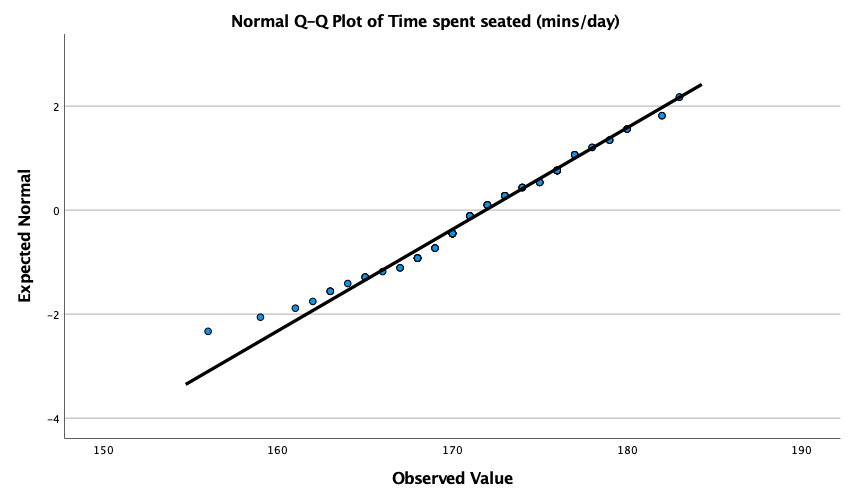

```python
img = os.path.join(path, 'static/images/pearsons/spss5.png')
Image(filename=img, width=600)
```

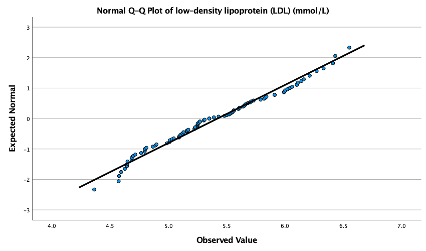

```python
img = os.path.join(path, 'static/images/pearsons/spss6.png')
Image(filename=img, width=600)
```

### Carry out Bivariate Pearson's Correlation.

**Procedure**

1. `Analyze > Correlate > Bivariate`
2. Bivariate Correlation Dialog box:
   - Move both variables to variables box.
   - Correlation coefficients box: make sure "Pearson" is checked off
   - Test for significance box: make sure radial dial for "Two-tailed" is selected
   - Click Options button > Options dialogue Box: Leave Check boxes for "Statistics" unchecked, and for missing values box, radial dial "Exclude cases pairwise" selected.
3. `Click "Continue" button`

**Interpretation of Results**

- The correlation coefficient can take values from +1 to -1.
- Step 1: look at your Pearson Correlation coefficient Time spent vs LDL: `0.371`
- Step 2: Determine if the results are statistically significant, `p-value <0.001`
- `Sig (2-tailed) < 0.05` there is statistically significant linear relationship between time seated and LDL levels.
- IF `Sig (2-tailed) ≥ 0.05` the test is not significant, and no evidence to suggest a linear relationship between variables.
- There was a statistically significant, moderate positive correlation between daily time spent seated and LDL concentration, r(98) = .37, p ≤ .0005.

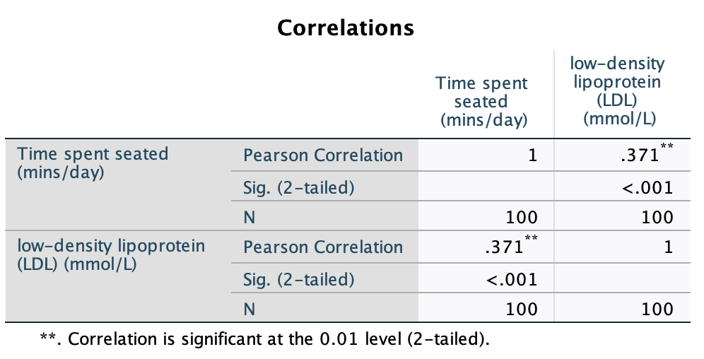

```python
img = os.path.join(path, 'static/images/pearsons/spss7.png')
Image(filename=img, width=700)
```

# Infographic Overview on Pearson's Correlation.

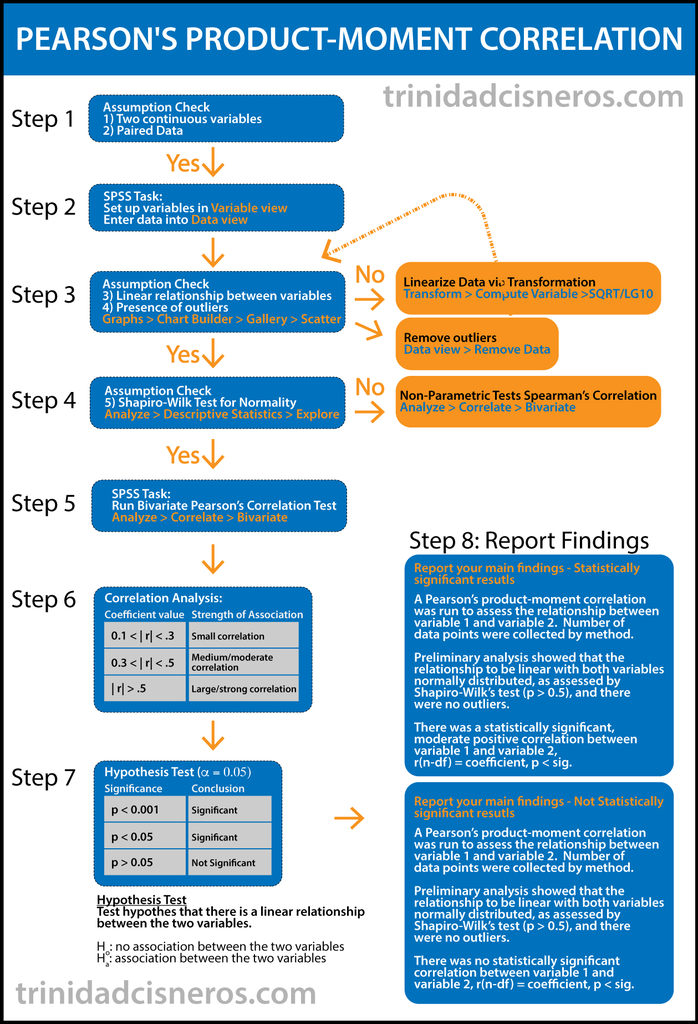

```python
img = os.path.join(path, 'static/images/pearsons/spss8.png')
Image(filename=img, width=700)
```